# Mestrado em Hemoterapia: Bioestatística

## Teste Qui-Quadrado

## Introdução

Muitas vezes, a informação da amostra coletada tem a estrutura de dados categorizados, ou seja, cada membro da população pode assumir um entre \(k\) valores distintos de uma ou mais características estudadas.

Desta forma, o conjunto de dados pode ser representado por frequências de contagens para essas categorias.

Esse tipo de dados são muito comuns nas áreas sociais e biomédicas.

O objetivo aqui é apresentar o **teste de qui-quadrado** para dados categóricos em diferentes contextos:

- *Teste de Aderência (ou Bondade de Ajuste)*
- *Teste de Independência*
- *Teste de Homogeneidade*

## Introdução

**Teste de Aderência:** considere uma população na qual cada membro assume qualquer um de \(k\) possíveis valores de uma dada característica. Iremos verificar quão adequado uma amostra obtida dessa população se ajusta a um modelo de probabilidade proposto.

> **Teste de Independência:** considere uma população na qual cada membro é classificado de acordo com duas características distintas. iremos testar, com os dados de uma amostra desta população, se as duas características são independentes.

Duas características serão independentes se a classificação de um membro da população de acordo com uma característica não interfere na probabilidade de classificação em relação a segunda característica desse mesmo membro.

## Introdução

**Teste de Homogeneidade:** Considere que temos duas ou mais populações e que os membro de cada população possa assumir um de \(k\) possíveis valores de uma dada carcaterística. O objetivo é testar se as populações são homogêneas, isto é, que as diferentes populações tem a mesma distribuição de inidividuos para a característica estudada.

## Teste de Aderência

## Exemplo

Em uma certa população uma dada característica de interesse foi estudada para 100 descendentes, e a seguinte tabela foi gerada:

| Genótipo | \(AA\) | \(Aa\) | \(aa\) | Total |
| --- | --- | --- | --- | --- |
| Frequência Observada | 26 | 45 | 29 | 100 |

\[ \]

**Objetivo:**

Verificar se a característica estudada nesta população segue o equilíbrio de Hardy-Weinberg (modelo proposto).

## Exemplo

Se o modelo teórico for adequado, a frequência esperada de descendentes para o genótipo \(AA\), dentre os 100 indivíduos, pode ser calculada por: \[100 \times P(AA) = 100 \times \frac{1}{4} = 25\]

Da mesma forma para o genótipo \(Aa\): \[100 \times P(Aa) = 100 \times \frac{1}{2} = 50\]

E para o genótipo \(aa\): \[100 \times P(aa) = 100 \times \frac{1}{4} = 25\]

## Exemplo

Podemos expandir a tabela de frequências dada anteriormente com as frequências esperadas sob o modelo teórico:

| Genótipo | \(AA\) | \(Aa\) | \(aa\) | Total |
| --- | --- | --- | --- | --- |
| Frequência Observada | 26 | 45 | 29 | 100 |
| Frequência Esperada | 25 | 50 | 25 | 100 |

> **Pergunta:**

Podemos afirmar que os valores observados estão suficientemente próximos dos valores esperados, de tal forma que o modelo genético teórico seja adequado a esta população?

> O procedimento que responde esse tipo de pergunta é chamado de **teste de bondade de ajuste** ou **teste de aderência**.

## Teste de Aderência

Considere uma tabela de frequências, com \(k \geq 2\) categorias de resultados:

| Categorias | \(1\) | \(2\) | … | \(k\) | Total |
| --- | --- | --- | --- | --- | --- |
| Frequência Observada | \(O_1\) | \(O_2\) | … | \(O_k\) | \(n\) |

Sendo \(O_i\) o total de indivíduos observados na categoria \(i\), \(i=1,2, \ldots, k\).

Seja \(p_i\) a probabilidade associada à categoria \(i\), \(i=1,2, \ldots, k\).

O objetivo do teste de aderência é testar as hipóteses

\[\begin{aligned} H_0: & p_1=p_{01}, \ldots , p_k= p_{0k} \\ H_a: & \mbox{existe pelo menos uma diferença} \end{aligned} \] sendo \(p_{0i}\) a probabilidade da categoria \(i\) sob o modelo teórico e \(\sum_{i=1}^k p_{0i} =1\)

## Procedimento

Se \(E_i\) é o total de indivíduos esperados na categoria \(i\), quando a hipótese nula \(H_0\) é verdadeira, então:

\[E_i = n\times p_{0i}, \quad i=1,2, \ldots, k.\]

Então, expandindo a tabela de frequências original, temos

| Categorias | \(1\) | \(2\) | … | \(k\) | Total |
| --- | --- | --- | --- | --- | --- |
| Frequência Observada | \(O_1\) | \(O_2\) | … | \(O_k\) | \(n\) |
| Frequência Esperada | \(E_1\) | \(E_2\) | … | \(E_k\) | \(n\) |

## Procedimento

Para quantificar quão distante os frequências observadas estão das frequências esperadas, usamos a seguinte estatística:

**Estatística do Teste**: \[\chi^2=\sum_{i=1}^k \frac{(O_i-E_i)^2}{E_i} = \sum^{k}_{i=1}\frac{(n_i-np_{0i})^2}{np_{0i}}\]

Se \(H_0\) é verdadeira: \(\chi^2 \sim \chi^2_{k-1}\)

Em outras palavras, se \(H_0\) é verdadeira, a v.a. \(\chi^2\) segue uma distribuição aproximadamente Qui-quadrado com \(k-1\) graus de liberdade.

**Condição**: Este resultado é válido para \(n\) grande e para frequências esperadas maiores ou iguais a 5.

## Procedimento

Calcular o **valor-de-p** ou encontrar o **valor crítico**.

**Valor-de-p**: \(P(\chi^2_{k-1} \geq \chi^2_{obs}),\) em que \(\chi^2_{obs}\) é o valor da estatística do teste calculada a partir dos dados.

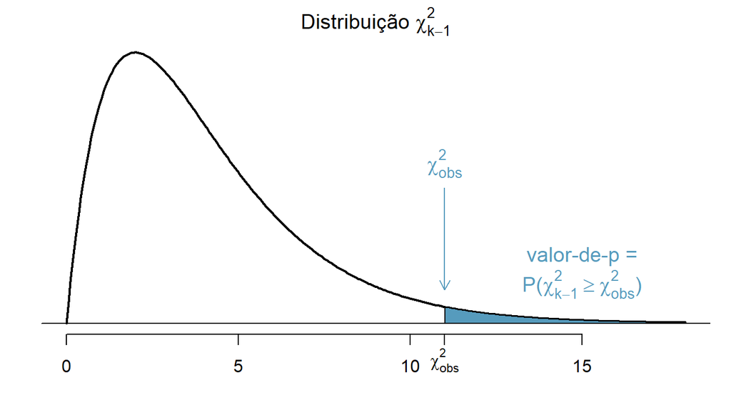

## Procedimento

**Valor Crítico**: Para um nível de significância \(\alpha\), encontrar o valor crítico \(\chi^2_{crit}\) na tabela Qui-quadrado tal que \(P(\chi^2_{k-1} \geq \chi^2_{crit}) = \alpha.\)

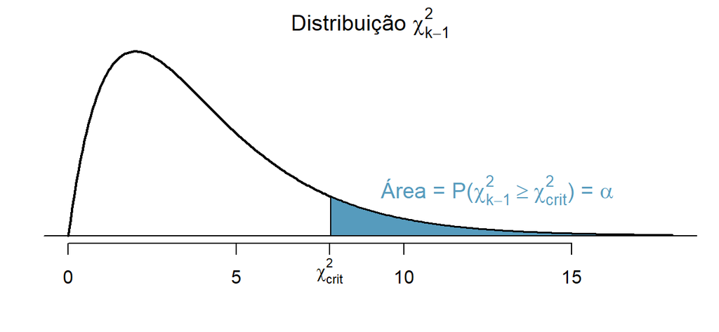

**Conclusão**: Rejeitamos \(H_0\) se

\[\mbox{valor-de-p} \leq \alpha \quad \mbox{ou} \quad \chi_{obs}^2 \geq \chi^2_{crit}\]

## Exemplo: Genética (continuação)

Voltando no exemplo da Genética

**Hipóteses:** \[\begin{aligned} H_0: & \mbox{o modelo proposto é adequado} \\ H_a: & \mbox{o modelo proposto não é adequado} \end{aligned} \]

Que de forma equivalente, podem ser escritas como: \[\begin{aligned} H_0: & \, p_1=1/4, p_2=1/2 , p_3= 1/4 \\ H_a: & \, \mbox{ao menos umas das desigualdades não verifica} \end{aligned} \] sendo \(p_1=P(AA)\), \(p_2=P(Aa)\) e \(p_3=P(aa)\).

## Exemplo: Genética (continuação)

A tabela seguinte apresenta os valores observados e esperados (calculados anteriormente).

| Genótipo | \(AA\) | \(Aa\) | \(aa\) | Total |
| --- | --- | --- | --- | --- |
| Frequência Observada | 26 | 45 | 29 | 100 |
| Frequência Esperada | 25 | 50 | 25 | 100 |

**Estatística do Teste**: \[ \begin{aligned} \chi^2_{obs} &= \sum_{i=1}^3 \frac{(O_i-E_i)^2}{E_i} = \frac{(26-25)^2}{25} + \frac{(45-50)^2}{50} + \frac{(29-25)^2}{25} \\ &= 0.04 + 0.5 + 0.64 = 1.18 \end{aligned} \]

## Exemplo: Genética (continuação)

Sob \(H_0\), a estatística \(\chi^2 \sim \chi^2_2\). Veja que os graus de liberdade é o número de categorias menos 1. Então o valor-de-p é dado por:

\[\mbox{valor-de-p} = P(\chi^2_2 \geq \chi^2_{obs}) = P(\chi^2_2 \geq 1.18) = 0.554\] o valor crítico é: \(\chi^2_{crit} = 5.991\)

**Conclusão:** Para \(\alpha = 0.05\), como valor-de-p\(= 0.554 > 0.05\), não temos evidências estatística para rejeitar a hipótese \(H_0\), isto é, essa população segue o modelo genético proposto.

Ou como \(\chi^2_{obs}=1.18 < 5.991 = \chi^2_{crit},\) não rejeitamos a hipótese \(H_0\).

## Exemplo: Genética (continuação)

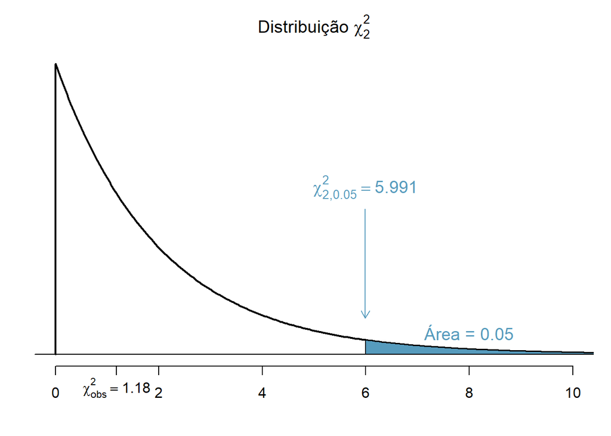

## Exemplo: Cores de Geladeira

Uma determinada marca de geladeira é vendida em cinco cores diferentes e uma pesquisa de mercado quer avaliar a popularidade das várias cores.

As frequências abaixo são observadas para uma amostra de 300 vendas feitas num semestre.

Vendas das cinco cores das geladeiras da marca W

| Cor | marrom | creme | vermelho | azul | branco | total |
| --- | --- | --- | --- | --- | --- | --- |
| Frequência | 88 | 65 | 52 | 40 | 55 | 300 |

Suponha que seja de interesse testar a hipótese das cinco cores serem igualmente populares.

\[\begin{aligned} H_0: & p_1=p_2= \ldots = p_5= 1/5 \\ H_a: & \mbox{existe pelo menos uma diferença} \end{aligned} \]

## Exemplo: Cores de Geladeira

| Componente | marrom | creme | vermelho | azul | branco | total |
| --- | --- | --- | --- | --- | --- | --- |
| Frequência Observada | 88 | 65 | 52 | 40 | 55 | 300 |

Como as probabilidades das componentes na hipótese nula são todas iguais, as frequências esperadas também serão todas iguais, ou seja, \[E_i = n\times \frac{1}{5} = 300\times \frac{1}{5} = 60, \quad i=1,2,3,4,5.\]

## Exemplo: Cores de Geladeira

| Componente | marrom | creme | vermelho | azul | branco | total |
| --- | --- | --- | --- | --- | --- | --- |
| Frequência Observada | 88 | 65 | 52 | 40 | 55 | 300 |
| Frequência Esperada | 60 | 60 | 60 | 60 | 60 | 300 |
| \(\displaystyle \frac{(O-E)^2}{E}\) | 13.07 | 0.42 | 1.07 | 6.67 | 0.42 | 21.63 |

**Estatística do Teste:** \[\begin{aligned} \chi^2=\sum_{i=1}^5 \frac{(O_i-E_i)^2}{E_i} &= 13.07 + 0.42 + 1.07 + 6.67 + 0.42 \\ &= 21.63 \end{aligned} \]

## Exemplo: Cores de Geladeira

Olhando na tabela qui-quadrado com 4 graus de liberdade, para \(\alpha=0.05\), o valor crítico é \(\chi^2_{crit} = \chi^2_{4, 0.05} = 9.488\).

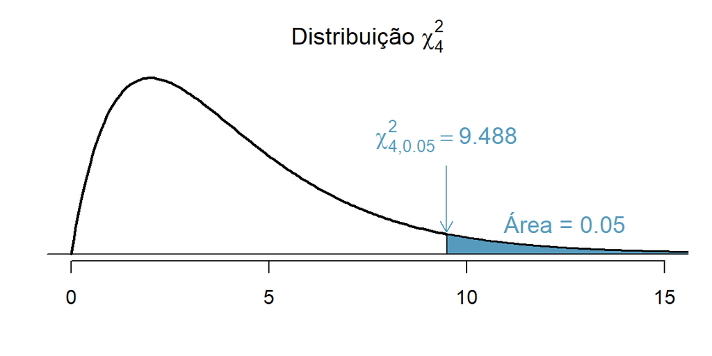

**Conclusão:** Para \(\alpha = 0.05\), como \(\chi^2_{obs}= 21.63 > 9.488 = \chi^2_{crit},\) rejeitamos a hipótese de que as cinco cores são igualmente populares.

## Exemplo: Tipo Sanguíneo

Entre os americanos, 41% tem sangue do tipo A, 9% tem sangue tipo B, 4% tipo AB e 46% tem sangue tipo O.

Em uma amostra aleatória de 200 pacientes americanos com câncer de estômago, 92 pacientes têm sangue do tipo A, 20 do tipo B, 4 do tipo AB e 84 do tipo O.

| Tipo | A | B | AB | O | total |
| --- | --- | --- | --- | --- | --- |
| Frequência Observada | 92 | 20 | 4 | 84 | 200 |

*Essas frequências observadas trazem evidência contra a hipótese de que a distribuição do tipo sanguíneo dos pacientes é igual a distribuição dos tipos sanguíneos na população geral americana?*

## Exemplo: Tipo Sanguíneo

\[\begin{aligned} H_0: & p_1=0.41, p_2=0.09, p_3=0.04 , p_4=0.46 \\ H_a: & \mbox{existe pelo menos uma diferença} \end{aligned} \]

| Tipo | A | B | AB | O | total |
| --- | --- | --- | --- | --- | --- |
| Frequência Observada | 92 | 20 | 4 | 84 | 200 |
| Frequência Esperada | 82 | 18 | 8 | 92 | 200 |
| \(\displaystyle \frac{(O-E)^2}{E}\) | 1.22 | 0.22 | 2 | 0.7 | 4.14 |

**Estatística do Teste:** \(\displaystyle \chi^2=\sum_{i=1}^4 \frac{(O_i-E_i)^2}{E_i} = 4.14\)

## Exemplo: Tipo Sanguíneo

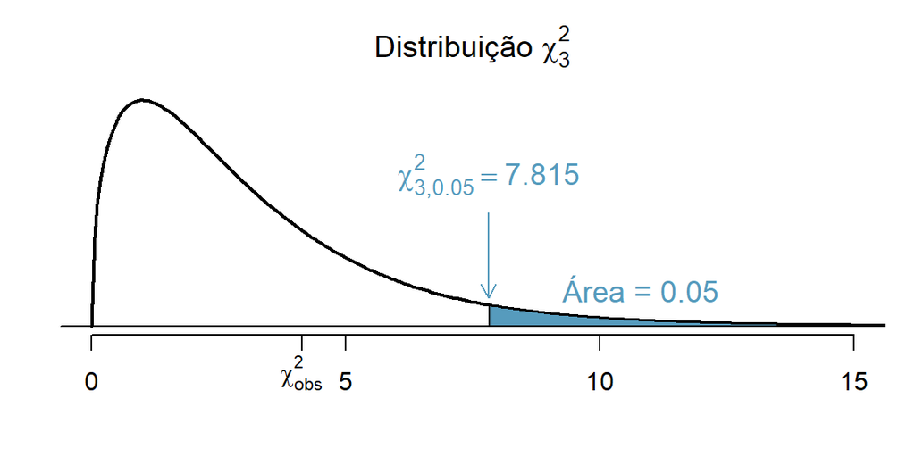

**Conclusão**: Como \(\chi^2_{obs} = 4.14 \leq 7.815= \chi^2_{3, 0.05}\), não temos evidência para rejeitar a hipótese nula.

Portanto, concluímos que não há discrepância significativa entre o que foi observado e a distribuição sanguínea da população americana.

## Exemplo: Ervilhas de Mendel

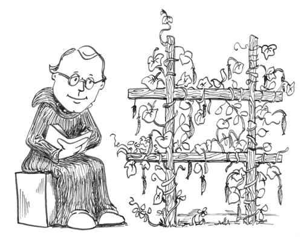

## Exemplo: Ervilhas de Mendel

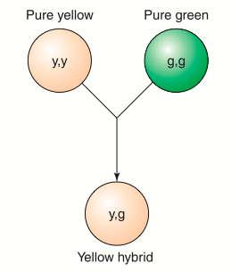

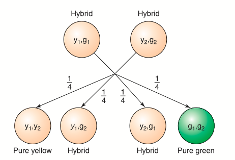

*Figura: (Esquerda) Cruzamento de ervilhas puramente amarelas e puramente verdes e (Direta) cruzamento de ervilhas híbridas (Direita)*

## Exemplo: Ervilhas de Mendel

Mendel fez o cruzamento de 8023 ervilhas híbridas e o resultado foram 6022 ervilhas amarelas e 2001 ervilhas verdes. Teoricamente, cada cruzamento deve resultar em ervilha amarela com probabilidade \(3/4\) e verde com probabilidade \(1/4\).

\[\begin{aligned} H_0: & p_1=3/4 \; \mbox{ e } \; p_2=1/4 \\ H_a: & \mbox{existe pelo menos uma diferença} \end{aligned} \]

| Tipo | Amarela | Verde | total |
| --- | --- | --- | --- |
| Frequência Observada | 6022 | 2001 | 8023 |
| Frequência Esperada | 6017.25 | 2005.75 | 8023 |
| \(\displaystyle \frac{(O-E)^2}{E}\) | 0.004 | 0.011 | 0.015 |

## Exemplo: Ervilhas de Mendel

**Estatística do Teste:** \(\displaystyle \chi^2=\sum_{i=1}^2 \frac{(O_i-E_i)^2}{E_i} = 0.015\)

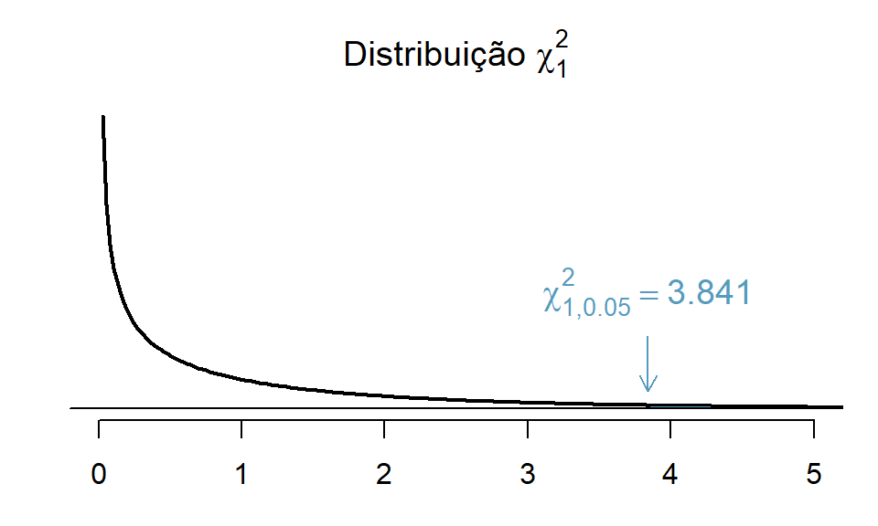

**Conclusão:** Como \(\chi^2_{obs} = 0.015 \leq 3.841= \chi^2_{1, 0.05}\), não temos evidência para rejeitar a hipótese nula. Concluímos que não há discrepância significativa entre o que foi observado e a hipótese nula.

## Leituras

- [Ross](http://www.sciencedirect.com/science/article/pii/B9780123743886000132): capítulo 13.
- [OpenIntro](https://www.openintro.org/stat/textbook.php): seção 6.3

## Teste de Independência

## Tabela de contingência

Quando dois ou mais atributos são observados para cada elemento amostrado, os dados podem ser simultaneamente classificados com respeito aos níveis de ocorrência para cada um dos atributos.

> Por exemplo, empregados podem ser classificados de acordo com escolaridade e tipo de ocupação, flores podem ser classificadas com respeito ao tipo de folhagem e tamanho.

**Tabela de contingência:** enumerar a frequência de obervações da classificação simultânea de duas ou mais características.

Podemos usar a tabela de contingência para estudar se certa característica parece se manifestar independentemente da outra ou se níveis de uma característica tendem a estar associados com níveis da outra.

## Exemplo: Racionamento de energia

Uma amostra aleatória de 500 pessoas responde um questionário sobre filiação partidária (partido \(A\) ou \(B\)) e atitude mediante um programa de racionamento de energia. Os resultados estão apresentados na tabela de contingência a seguir:

|  | Favorável | Indiferente | Contrário |
| --- | --- | --- | --- |
| A | 138 | 83 | 64 |
| B | 64 | 67 | 84 |

Os dados indicam que a opinião sobre racionamento de energia é independente da filiação partidária?

Podemos medir quantitativamente a associação entre as duas características?

## Exemplo: Racionamento de energia

Primeiramente, consideremos a tabela de um ponto de vista descritivo, transformando as contagens em proporcões.

- Proporções por caselas

|  | Favorável | Indiferente | Contrário | Total |
| --- | --- | --- | --- | --- |
| A | 0.28 | 0.17 | 0.13 | 0.57 |
| B | 0.13 | 0.13 | 0.17 | 0.43 |
| Total | 0.4 | 0.3 | 0.3 | 1.00 |

## Exemplo: Racionamento de energia

Primeiramente, consideremos a tabela de um ponto de vista descritivo, transformando as contagens em proporcões.

- Proporções por linhas

|  | Favorável | Indiferente | Contrário | Total |
| --- | --- | --- | --- | --- |
| A | 0.48 | 0.29 | 0.22 | 1.00 |
| B | 0.3 | 0.31 | 0.39 | 1.00 |

## Exemplo: Racionamento de energia

Primeiramente, consideremos a tabela de um ponto de vista descritivo, transformando as contagens em proporções.

- Proporções por colunas

|  | Favorável | Indiferente | Contrário |
| --- | --- | --- | --- |
| A | 0.68 | 0.55 | 0.43 |
| B | 0.32 | 0.45 | 0.57 |
| Total | 1.00 | 1.00 | 1.00 |

## Exemplo: Racionamento de energia

- Gráficos de barras: Frequências relativas (caselas, linhas e colunas)

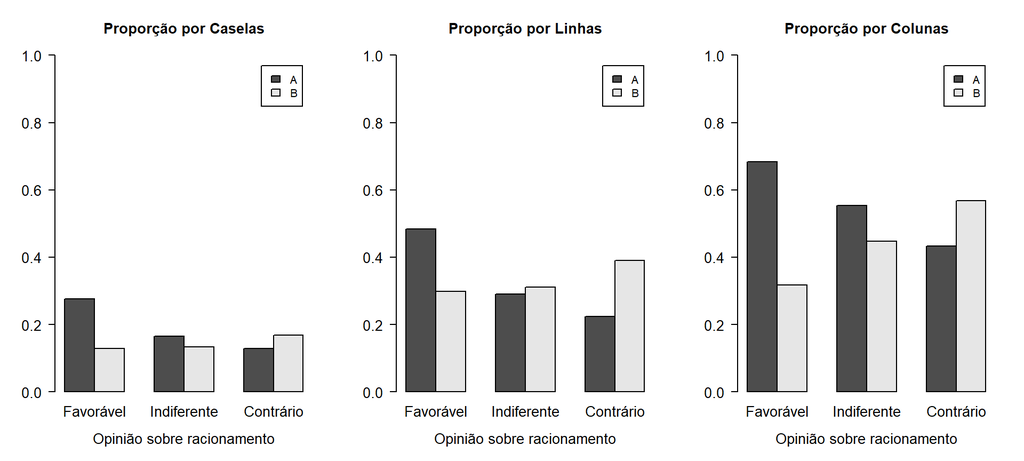

## Exemplo: Racionamento de energia

Através das tabelas de proporções e gráficos de barras, observam-se diferenças aparentes nas distribuições ao longo das linhas, colunas ou das proporções totais das respostas.

Por exemplo, com relação as proporções por linha, observa-se que as proporções diminuem ao longo da primeira linha e aumentam ao longo da segunda.

Podemos usar um teste estatístico para avaliar possível associação entre filiação partidária e opinião com relação ao programa de racionamento de energia.

## Teste de Independência

Considere duas características designadas por \(A\) e \(B\) e suponha que existem \(r\) categorias \(A_1,A_2, \ldots , A_r\) para \(A\) e \(c\) categorias \(B_1, B_2, \ldots, B_c\) para \(B\).

Suponha que uma amostra de tamanho \(n\) seja classificada e distribuída nas classes de \(A\) e \(B\), produzindo uma tabela de contingência em que:

\(n_{ij}=\) frequência de observações com as características \(A_i\) e \(B_j\) conjuntamente.

\(n_{i0}=\) total da \(i\)-ésima linha, ou frequência de \(A_i\).

\(n_{0j}=\) total da \(j\)-ésima coluna, ou frequência de \(B_j\).

## Teste de Independência

|  | \(B_1\) | \(B_2\) | \(\ldots\) | \(B_c\) | Total da linha |
| --- | --- | --- | --- | --- | --- |
| \(A_1\) | \(n_{11}\) | \(n_{12}\) | \(\ldots\) | \(n_{1c}\) | \(n_{10}\) |
| \(A_2\) | \(n_{21}\) | \(n_{22}\) | \(\ldots\) | \(n_{2c}\) | \(n_{20}\) |
| \(\vdots\) | \(\vdots\) | \(\vdots\) | \(\vdots\) | \(\vdots\) | \(\vdots\) |
| \(A_r\) | \(n_{r1}\) | \(n_{r2}\) | \(\ldots\) | \(n_{rc}\) | \(n_{r0}\) |
| Total da coluna | \(n_{01}\) | \(n_{02}\) | \(\ldots\) | \(n_{0c}\) | \(n\) |

## Teste de Independência

Podemos usar a população classificada em termos de proporções populacionais e a tabela anterior fica:

|  | \(B_1\) | \(B_2\) | \(\ldots\) | \(B_c\) | Total da linha |
| --- | --- | --- | --- | --- | --- |
| \(A_1\) | \(p_{11}\) | \(p_{12}\) | \(\ldots\) | \(p_{1c}\) | \(p_{10}\) |
| \(A_2\) | \(p_{21}\) | \(p_{22}\) | \(\ldots\) | \(p_{2c}\) | \(p_{20}\) |
| \(\vdots\) | \(\vdots\) | \(\vdots\) | \(\vdots\) | \(\vdots\) | \(\vdots\) |
| \(A_r\) | \(p_{r1}\) | \(p_{r2}\) | \(\ldots\) | \(p_{rc}\) | \(p_{r0}\) |
| Total da coluna | \(p_{01}\) | \(p_{02}\) | \(\ldots\) | \(p_{0c}\) | \(1\) |

\(p_{ij}=P(A_i \cap B_j)\) é a probabilidade da ocorrência conjunta de \(A_i\) e \(B_j\).

\(p_{i0}=P(A_{i})\) é a probabilidade total da \(i\)-ésima linha.

\(p_{0j}=P(B_{j})\) é a probabilidade total da \(j\)-ésima coluna.

## Teste de Independência

**Teste de independência:** interesse é testar se as classificações nas categorias de \(A\) e \(B\) são independentes, ou seja, pretende-se avaliar se \[P(A_i\cap B_j)=P(A_i)P(B_j)\] para todo \(i=1,2, \ldots , r\) e \(j=1,2, \ldots , c\)

## Teste de Independência

**Hipóteses:**

\(H_0: p_{ij}=p_{i0}p_{0j}\) para todas as componentes \((i,j)\) (**independência**)

\(H_a: p_{ij} \neq p_{i0}p_{0j}\) para pelo menos um par \((i,j)\)

O modelo de independência especifica as probabilidades das componentes em termo das probabilidades marginais. **Problema:** as probabilidades marginais são parâmetros desconhecidos.

Como \(p_{i0}=P(A_i)\), um estimador natural é a frequência relativa amostral de \(A_i\),

\(\displaystyle \hat{p}_{i0}=\frac{n_{i0}}{n}\)

Da mesma forma, \(p_{0j}=P(B_j)\) é estimada por

\(\displaystyle \hat{p}_{0j}=\frac{n_{0j}}{n}\)

## Teste de Independência

Usando essas estimativas a probabilidade da componente \((i,j)\) é estimada por \[\hat{p}_{ij}=\hat{p}_{i0}\hat{p}_{0j}=\frac{n_{i0}n_{0j}}{n^2}\]

Logo, a frequência relativa esperada sob o modelo de independência é

\[E_{ij}=n \hat{p}_{ij} = \frac{n_{i0}n_{0j}}{n}\]

e a **estatística do teste** é dada por

\[\chi^2= \sum_{r\times c \text{ componentes }}\frac{(O_{ij}-E_{ij})^2}{E_{ij}} = \sum_{r\times c \text{ componentes }}\frac{(n_{ij}-E_{ij})^2}{E_{ij}}\]

que sob \(H_0\) tem distribuição aproximadamente \(\chi^2\) com \((r-1)\times(c-1)\) graus de liberdade, para \(n\) grande.

## Exemplo: Racionamento de energia

Frequências observadas (\(n_{ij}\)):

|  | Favorável | Indiferente | Contrário |
| --- | --- | --- | --- |
| A | 138 | 83 | 64 |
| B | 64 | 67 | 84 |

Frequências esperadas (\(E_{ij}\)) segundo a hipótese de independência:

|  | Favorável | Indiferente | Contrário |
| --- | --- | --- | --- |
| A | 115.14 | 85.5 | 84.36 |
| B | 86.86 | 64.5 | 63.64 |

## Exemplo: Racionamento de energia

A estatística \(\chi^2\) tem o valor observado de

\[\chi^2_{obs}=4.539 + 0.073 + 4.914 + 6.016 + 0.097 + 6.514=22.15 \stackrel{H_0}{\sim} \chi^2_{2}\]

Usando o nível de significância \(\alpha=0.05\), o valor crítico é \(\chi^2_{crit} = \chi^2_{2, 0.05} = 5.99\).

Como \(\chi^2_{obs}= 22.15 > 5.99 = \chi^2_{crit}\), rejeitamos a hipótese nula de indepêndencia.

Concluímos que os dados trazem evidências de **associação** entre as duas características (filiação e opinião).

**CUIDADO!!!** Não podemos afirmar que existe uma relação de causa e efeito, pois os dados são observacionais, isto é, não aleatorizamos as pessoas para serem do partido \(A\) ou \(B\), por exemplo.

## Exemplo: Estudo sobre cancer intestinal

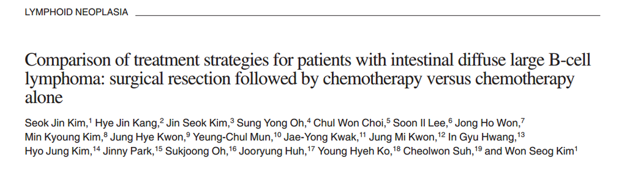

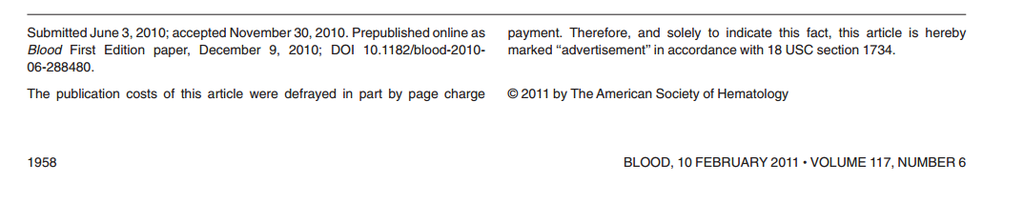

## Exemplo: Estudo sobre cancer intestinal

Estudo retrospectivo de coorte, entre 1993 e 2009, com 345 pacientes diagnosticados com *primary intestinal diffuse large B-cell lymphomas (DLBCL)*.

**Duas estratégias de tratamento** cirurgia+quimioterapia ou quimioterapia.

Os pacientes foram ainda agrupados de acordo com o estágio da doença segundo a escala Lugado : I/II e IV.

Várias características foram observadas como: idade, tipo de quimioterapia entre outras.

## Exemplo: Estudo sobre cancer intestinal

**Pergunta** Entre os pacientes classificados com Lugano I/II, existe associação entre o tipo de tratamento e uma não recidiva ou progressão da doença?

Frequências observadas (\(n_{ij}\)):

[output not shown]

## Exemplo: Estudo sobre cancer intestinal

Frequências esperadas (\(E_{ij}\)), segundo hipótese de independência:

|  | Cirurgia/Quimio | Quimio |
| --- | --- | --- |
| Local | 24.776 | 13.224 |
| Sistemática | 12.388 | 6.612 |
| Nenhuma | 125.836 | 67.164 |

## Exemplo: Estudo sobre cancer intestinal

A estatística \(\chi^2\) tem o valor observado de

\[ \chi^2_{obs} = \frac{(14-24.7)^2}{24.7}+ \frac{(24-13.2)^2}{13.2}+ \frac{(11-12.4)^2}{12.4}+ \frac{(8-6.6)^2}{6.6} + \] \[\frac{(138-125.8)^2}{125.8}+ \frac{(55-67.1)^2}{67.1}=17.294 \stackrel{H_0}{\sim} \chi^2_{2} \] Ao nível de significância \(\alpha=0.05\), o valor crítico é \(\chi^2_{crit} = \chi^2_{2, 0.05} = 5.99\).

Como \(\chi^2_{obs}= 17.294 > 5.99 = \chi^2_{crit}\) e o valor-de-p é = 0,0001, temos evidências para rejeitar a hipótese nula de indepêndencia.

## Exemplo: Estudo sobre cancer intestinal

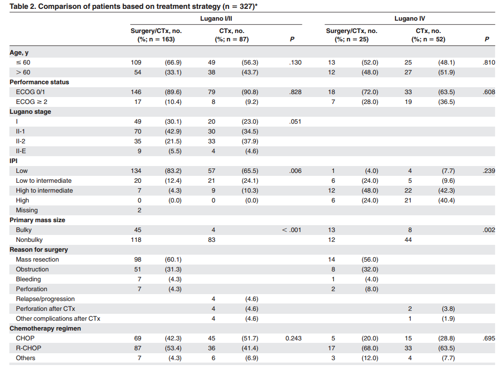

## Teste de Homogeneidade

## Teste de Homogeneidade

Nas situações em que utilizamos os testes de independência, o esquema de amostragem utilizado foi baseado numa amostra aleatória de tamanho \(n\) que é classificada com respeito a duas características simultaneamente.

Nesse caso, as frequências marginais totais (totais por linhas e totais por colunas) são variáveis aleatórias, pois a cada nova amostragem, não temos como saber de antemão quais serão os valores dos totais por linhas/colunas.

Se o esquema de amostragem for de dividir a população em duas subpopulaÃções de acordo com as categorias de uma característica e selecionar uma amostra de um tamanho pré-determinado para cada subpopulação, então esta será uma situação de tabela de contingência com margens fixas.

## Teste de Homogeneidade

Por exemplo, no caso do problema de filiação partidária, poderiamos selecionar amostras aleatórias de tamanho \(200\) entre afiliados do partido \(A\) e \(300\) dentre os afiliados do partido \(B\) e se classificaria essas amostras de acordo com a atitude (favorável, indiferente ou contrário).

O interesse então seria estudar as proporções nessas categorias para determinar se elas são aproximadamente iguais para as diferentes subpopulações. Ou seja, queremos testar se as subpopulações são homogêneas.

## Teste de Homogeneidade

Suponha que amostras aleatórias independentes de tamanho \(n_{10}, \ldots, n_{r0}\) são selecionadas de \(r\) subpopulações \(A_1, \ldots, A_r\) respectivamente. Classificando cada amostra em uma das categorias \(B_1, \ldots, B_c\), obtemos uma tabela de contigência \(r \times c\) onde os totais das linhas são tamanhos de amostras fixos.

Tabelas de contingência \(r \times c\) com totais das linhas fixos:

|  | \(B_1\) | \(B_2\) | \(\ldots\) | \(B_c\) | Total da linha |
| --- | --- | --- | --- | --- | --- |
| \(A_1\) | \(n_{11}\) | \(n_{12}\) | \(\ldots\) | \(n_{1c}\) | \(n_{10}\) |
| \(A_2\) | \(n_{21}\) | \(n_{22}\) | \(\ldots\) | \(n_{2c}\) | \(n_{20}\) |
| \(\vdots\) | \(\vdots\) | \(\vdots\) | \(\vdots\) | \(\vdots\) | \(\vdots\) |
| \(A_r\) | \(n_{r1}\) | \(n_{r2}\) | \(\ldots\) | \(n_{rc}\) | \(n_{r0}\) |
| Total da coluna | \(n_{01}\) | \(n_{02}\) | \(\ldots\) | \(n_{0c}\) | \(n\) |

## Teste de Homogeneidade

As probabilidades das várias categorias de \(B\) dentro de cada subpopulação de \(A\) também são apresentadas a seguir, onde cada \(w\) representa uma probabilidade condicional,

\[w_{ij}=P(B_j| A_i)= \text{ probabilidade de } B_j \text{ dentro da população } A_i.\]

Probabilidades das categorias de \(B\) dentro de cada subpopulação:

|  | \(B_1\) | \(B_2\) | \(\ldots\) | \(B_c\) | Total da linha |
| --- | --- | --- | --- | --- | --- |
| \(A_1\) | \(w_{11}\) | \(w_{12}\) | \(\ldots\) | \(w_{1c}\) | \(1\) |
| \(A_2\) | \(w_{21}\) | \(w_{22}\) | \(\ldots\) | \(w_{2c}\) | \(1\) |
| \(\vdots\) | \(\vdots\) | \(\vdots\) | \(\vdots\) | \(\vdots\) | \(\vdots\) |
| \(A_r\) | \(w_{r1}\) | \(w_{r2}\) | \(\ldots\) | \(w_{rc}\) | \(1\) |

## Teste de Homogeneidade

A hipótese nula de igualdade das categorias \(B\) para as \(r\) subpopulações é:

\[H_0: w_{1j}=w_{2j}= \cdots = w_{rj}, \mbox{ para todo } j=1,2, \ldots c.\]

Sob \(H_0\), a probabilidade comum da categoria \(B_j\) pode ser estimada do conjunto de amostras notando que de um total de \(n\) elementos amostrados, \(n_{0j}\) possuem a característica \(B_j\), daí a probabilidade estimada fica

\[\hat{w}_{1j}=\hat{w}_{2j}= \cdots =\hat{w}_{rj}= \frac{n_{0j}}{n}\]

A frequência esperada estimada na componente \((i,j)\) sob \(H_0\) é:

\(E_{ij}=\)(Número de \(A_i\) amostrados)\(\times\)(Probabilidade de \(B_j\) dentro de \(A_i\))\(=n_{i0} \hat{w}_{ij}=\frac{n_{i0}n_{0j}}{n}.\)

## Teste de Homogeneidade

A **estatística do teste** é dada por:

\[\chi^2= \sum_{r \times c \text{ componentes }} \frac{(n_{ij}-E_{ij})^2}{E_{ij}}\] que sob \(H_0\) segue uma distribuição \(\chi^2\) com \((r-1)\times(c-1)\) graus de liberdade.

Pode-se observar que as fórmulas e os graus de liberdade dessa seção são iguais ao da seção anterior, somente o método de amostragem e a formalização da hipótese nula são diferentes.

## Exemplo: Alcoolismo e profissões

Foi feita uma pesquisa para determinar a incidência de alcoolismo em diferentes grupos profissionais. Foram coletadas amostras aleatórias entre religiosos, educadores, executivos e comerciantes, respectivamente. A frequências observadas são apresentadas abaixo.

|  | Alcoólatras | Não Alcoólatras |
| --- | --- | --- |
| Religiosos | 32 | 268 |
| Educadores | 51 | 199 |
| Executivos | 67 | 233 |
| Comerciantes | 83 | 267 |
| Total | 233 | 967 |

## Exemplo: Alcoolismo e profissões

Tabela de contingência de alcoolismo vs profissão: frequência relativa por linha.

|  | Alcoólatras | Não Alcoólatras |
| --- | --- | --- |
| Religiosos | 0.11 | 0.89 |
| Educadores | 0.20 | 0.80 |
| Executivos | 0.22 | 0.78 |
| Comerciantes | 0.24 | 0.76 |
| Total | 0.19 | 0.81 |

## Exemplo: Alcoolismo e profissões

Gráfico de barras de alcoolismo vs profissão: frequência relativa por linha.

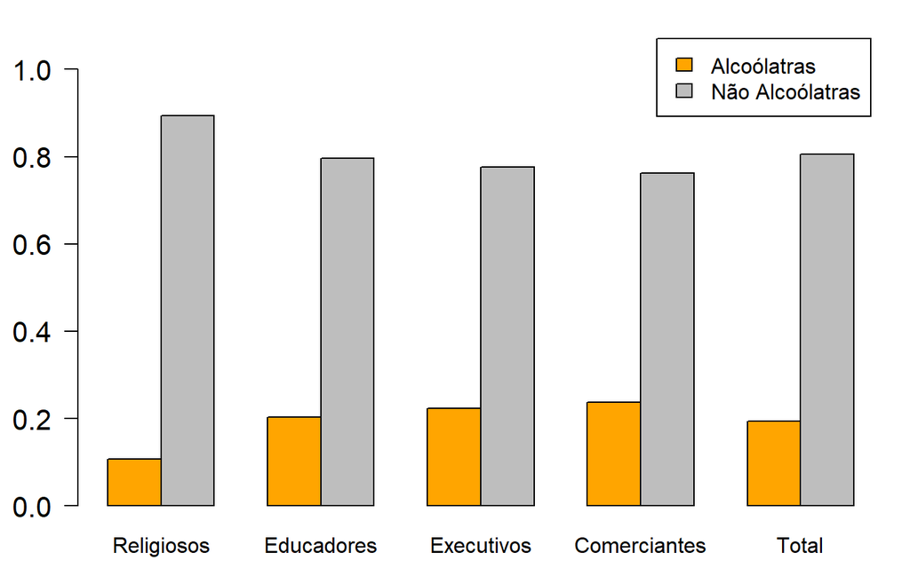

## Exemplo: Alcoolismo e profissões

A frequência esperada estimada na componente \((i,j)\) sob \(H_0\) é \(E_{ij}=\frac{n_{i0}n_{0j}}{n}\)

Tabela de frequências esperadas, segundo a hipótese nula de homogeneidade:

|  | Alcoólatras | Não Alcoólatras |
| --- | --- | --- |
| Religiosos | 58.25 | 241.75 |
| Educadores | 48.54 | 201.46 |
| Executivos | 58.25 | 241.75 |
| Comerciantes | 67.96 | 282.04 |
| Total | 233.00 | 967.00 |

## Exemplo: Alcoolismo e profissões

Representando por \(p_1, p_2, p_3\) e \(p_4\) as proporções de alcoólatras na subpopulação de religiosos, educadores, executivos e comerciantes, respectivamente, queremos testar a hipótese:

\[H_0: p_1= p_2 = p_3 = p_4 \quad \mbox{vs} \quad H_a: \mbox{pelo menos uma proporção é diferente}\]

Como a hipótese nula foi rejeitada verificamos que há indícios de que a proporção de alcoólatras nas classes profissionais não é homogênea.

## Exemplo: Google

O Google está constantemente elaborando experimentos para testar novos algoritmos de busca. Por exemplo, o Google pode estar interessado em testar 3 algoritmos usando uma amostra aleatória para cada um: 5000 buscas feitas com o algoritmo atual foram selecionadas ao acaso, 2500 buscas feitas com o algoritmo teste 1 foram selecionadas ao acaso e 2500 buscas feitas com o algoritmo teste 2 foram selecionadas ao acaso.

Como avaliar qual o melhor algoritmo? É preciso definir alguma medida.

No caso, o Google irá avaliar se o usuário clicou em um dos links da busca e depois não realizou uma nova tentativa de busca ou se ele depois realizou nova tentativa (indicando que a primeira busca não foi bem sucedida).

**Pergunta:** Os três algoritmos têm a mesma performance, isto é, a proporção de buscas que não são refeitas é a mesma para os três algoritmos?

## Exemplo: Google

Suponha que o Google tenha obtido os seguintes resultados:

|  | Atual | Teste 1 | Teste 2 |
| --- | --- | --- | --- |
| Sem nova busca | 3511 | 1749 | 1818 |
| nova busca | 1489 | 751 | 682 |

Tabela de frequências esperadas, segundo a hipótese nula de homogeneidade:

|  | Atual | Teste 1 | Teste 2 |
| --- | --- | --- | --- |
| Sem nova busca | 3539 | 1769.5 | 1769.5 |
| nova busca | 1461 | 730.5 | 730.5 |

## Exemplo: Google

Sejam \(p_1\) a probabiliade de nova busca para o o algoritmo atual, \(p_2\) para o teste 1 e \(p_3\) para o teste 2.

\[H_0 : p_1 = p_2 = p3 \mbox{ vs } H_a : \mbox{há pelo menos uma diferença}\]

A estatística \(\chi^2\) tem o valor observado de

\(\chi^2_{obs}=\frac{(3511-3539)^2}{3539}+\frac{(1749-1769.5)^2}{1769.5}+\frac{(1489-1461)^2}{1461}+\frac{(751-730.5)^2}{730.5}=6.12 \stackrel{H_0}{\sim} \chi^2_{2}\)

Usando o nível de significância \(\alpha=0.01\), o \(\chi^2\) tabulado é \(9.21\) que é maior do que o observado e portanto a hipótese nula de homogeneidade não é rejeitada.

## Exemplo: Google

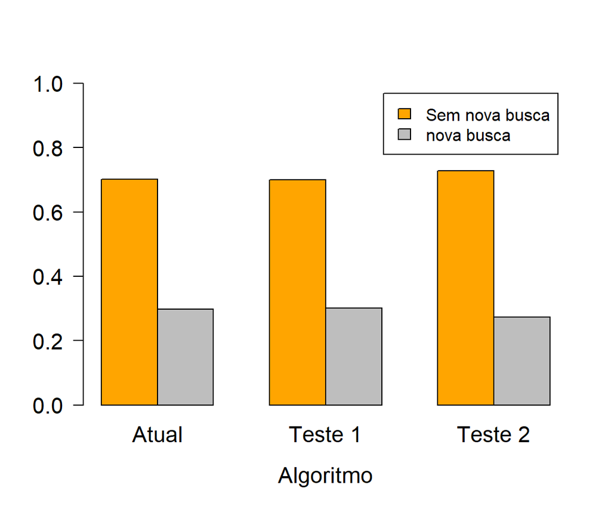

## Teste exato de Fisher

## Teste exato de Fisher

O teste exato de Fisher testa diferenças entre duas pooulações independentes (G1 e G2), em relação a uma variável qualquer que só admita duas alternativas como resposta: Sim/Não, Positivo/Negativo, ou +/-. Isso leva à construção de uma tabela de contingência 2 x 2.

O teste é basicamente um \(\chi^2\) (qui-quadrado), porém o teste de Fisher é particularmente adequado para pequenas amostras (com 20 dados ou menos), caso em que o teste do \(\chi^2\) estaria contra-indicado.

O teste exado de Fisher se caracteriza em fornecer diretamente o valor de p, sem uso de uma estatística intermediária.

Em compensação quando o número de dados da amostra é grande, o teste de Fisher é que não deve ser usado, porque envolve o cálculo de fatoriais, o que pode conduzir a números excessivamente elevados. Nesses casos, a opção deve ser pelo teste do \(\chi^2\).

## Leituras

- [Ross](http://www.sciencedirect.com/science/article/pii/B9780123743886000132): capítulo 13.
- [OpenIntro](https://www.openintro.org/stat/textbook.php): seção 6.4

Slides produzidos pelos professores:

- Samara Kiihl
- Tatiana Benaglia
- Benilton Carvalho
- Rafael Maia